# **Priming Mindfulness Project 3**

## Scale Means

### …

Now that we have imputed the missing data, we are ready to calculate our scale means.

### Trait Self-Control

```r
# Reverse code BSCS items 2, 4, 6, 7
data <- data %>%
  mutate(across(starts_with("BSCS"), .names = "{col}r"))
data <- data %>%
  mutate(across(c(BSCS_2, BSCS_4, BSCS_6, BSCS_7), ~nice_reverse(.x, 5), .names = "{col}r"))

# Get mean BSCS
data <- data %>%
  mutate(BSCS = rowMeans(select(., BSCS_1r:BSCS_7r)))
```

### Trait Aggression

```r
# Reverse code BAQ item 7
data <- data %>%
  mutate(across(starts_with("BAQ"), .names = "{col}r"))

data <- data %>%
  mutate(across(BAQ_7, ~nice_reverse(.x, 7), .names = "{col}r"))

# Get sum of BAQ
data <- data %>%
  mutate(BAQ = rowMeans(select(., BAQ_1r:BAQ_12r)))
```

### Trait Mindfulness

```r
# Reverse code KIMS items 3-4, 8, 11-12, 14, 16, 18, 20, 22, 23-24, 27-28, 31-32, 35-36
data <- data %>%
  mutate(across(starts_with("KIMS"), .names = "{col}r"))

data <- data %>%
  mutate(across(all_of(paste0("KIMS_", c(3:4, 8, 11:12, 14, 16, 18, 20,
                                         22:24, 27:28, 31:32, 35:36))),
                ~nice_reverse(.x, 5), .names = "{col}r"))

# Get sum of KIMS
data <- data %>%
  mutate(KIMS = rowMeans(select(., KIMS_1r:KIMS_39r)))
```

### PANAS

```r
# No reverse scoring needed for PANAS.
data <- data %>%
  mutate(PANAS_pos = rowMeans(select(., paste0("PANAS_", seq(1, 10, 2)))),
         PANAS_neg = rowMeans(select(., paste0("PANAS_", seq(2, 10, 2)))))
```

### State Hostility

```r
# SHS: forgot to add back the two other scales, so no reverse scoring needed.

# Get sum of SHS and subscales
data <- data %>%
  mutate(SHS = rowMeans(select(., SHS_1:SHS_21)),
         SHS.mean = rowMeans(select(., SHS_1:SHS_14)),
         SHS.aggravation = rowMeans(select(., SHS_14:SHS_21)))
```

### Intensity * Duration

```r
# Create new variable blastintensity.duration
data <- data %>%
  mutate(blastintensity.duration = blastintensity * blastduration)
```

## Reliability

### …

Now that we have reversed our items, we can get the alphas for our different scales.

### Trait Self-Control

```r
data %>%
  select(BSCS_1r:BSCS_7r) %>%
  omega(nfactors = 1)
```

```
## Omega_h for 1 factor is not meaningful, just omega_t
```

```
## Omega
## Call: omegah(m = m, nfactors = nfactors, fm = fm, key = key, flip = flip,
##     digits = digits, title = title, sl = sl, labels = labels,
##     plot = plot, n.obs = n.obs, rotate = rotate, Phi = Phi, option = option,
##     covar = covar)
## Alpha:                 0.83
## G.6:                   0.84
## Omega Hierarchical:    0.83
## Omega H asymptotic:    1
## Omega Total            0.84
##
## Schmid Leiman Factor loadings greater than  0.2
##            g  F1*   h2   u2 p2
## BSCS_1r 0.71      0.50 0.50  1
## BSCS_2r 0.70      0.49 0.51  1
## BSCS_3r 0.58      0.34 0.66  1
## BSCS_4r 0.70      0.49 0.51  1
## BSCS_5r 0.46      0.21 0.79  1
## BSCS_6r 0.76      0.58 0.42  1
## BSCS_7r 0.61      0.37 0.63  1
##
## With Sums of squares  of:
##   g F1*
##   3   0
##
## general/max  21455663717891292   max/min =   1
## mean percent general =  1    with sd =  0 and cv of  0
## Explained Common Variance of the general factor =  1
##
## The degrees of freedom are 14  and the fit is  0.48
## The number of observations was  432  with Chi Square =  207.12  with prob <  0.0000000000000000000000000000000000019
## The root mean square of the residuals is  0.09
## The df corrected root mean square of the residuals is  0.12
## RMSEA index =  0.179  and the 10 % confidence intervals are  0.158 0.201
## BIC =  122.16
##
## Compare this with the adequacy of just a general factor and no group factors
## The degrees of freedom for just the general factor are 14  and the fit is  0.48
## The number of observations was  432  with Chi Square =  207.12  with prob <  0.0000000000000000000000000000000000019
## The root mean square of the residuals is  0.09
## The df corrected root mean square of the residuals is  0.12
##
## RMSEA index =  0.179  and the 10 % confidence intervals are  0.158 0.201
## BIC =  122.16
##
## Measures of factor score adequacy
##                                                  g F1*
## Correlation of scores with factors            0.92   0
## Multiple R square of scores with factors      0.85   0
## Minimum correlation of factor score estimates 0.70  -1
##
##  Total, General and Subset omega for each subset
##                                                  g  F1*
## Omega total for total scores and subscales    0.84 0.83
## Omega general for total scores and subscales  0.83 0.83
## Omega group for total scores and subscales    0.00 0.00
```

### Trait Aggression

```r
data %>%
  select(BAQ_1r:BAQ_12r) %>%
  omega(nfactors = 1)
```

```
## Omega_h for 1 factor is not meaningful, just omega_t
```

```
## Omega
## Call: omegah(m = m, nfactors = nfactors, fm = fm, key = key, flip = flip,
##     digits = digits, title = title, sl = sl, labels = labels,
##     plot = plot, n.obs = n.obs, rotate = rotate, Phi = Phi, option = option,
##     covar = covar)
## Alpha:                 0.85
## G.6:                   0.88
## Omega Hierarchical:    0.85
## Omega H asymptotic:    1
## Omega Total            0.85
##
## Schmid Leiman Factor loadings greater than  0.2
##            g  F1*   h2   u2 p2
## BAQ_1r  0.66      0.43 0.57  1
## BAQ_2r  0.57      0.33 0.67  1
## BAQ_3r  0.69      0.48 0.52  1
## BAQ_4r  0.26      0.07 0.93  1
## BAQ_5r  0.49      0.24 0.76  1
## BAQ_6r  0.70      0.49 0.51  1
## BAQ_7r  0.47      0.23 0.77  1
## BAQ_8r  0.70      0.49 0.51  1
## BAQ_9r  0.75      0.57 0.43  1
## BAQ_10r 0.48      0.23 0.77  1
## BAQ_11r 0.49      0.24 0.76  1
## BAQ_12r 0.49      0.24 0.76  1
##
## With Sums of squares  of:
##   g F1*
##   4   0
##
## general/max  29040477649456792   max/min =   1
## mean percent general =  1    with sd =  0 and cv of  0
## Explained Common Variance of the general factor =  1
##
## The degrees of freedom are 54  and the fit is  1.64
## The number of observations was  432  with Chi Square =  697.06  with prob <  0.00000000000000000000000000000000000000000000000000000000000000000000000000000000000000000000000000000000000000014
## The root mean square of the residuals is  0.12
## The df corrected root mean square of the residuals is  0.13
## RMSEA index =  0.166  and the 10 % confidence intervals are  0.155 0.177
## BIC =  369.37
##
## Compare this with the adequacy of just a general factor and no group factors
## The degrees of freedom for just the general factor are 54  and the fit is  1.64
## The number of observations was  432  with Chi Square =  697.06  with prob <  0.00000000000000000000000000000000000000000000000000000000000000000000000000000000000000000000000000000000000000014
## The root mean square of the residuals is  0.12
## The df corrected root mean square of the residuals is  0.13
##
## RMSEA index =  0.166  and the 10 % confidence intervals are  0.155 0.177
## BIC =  369.37
##
## Measures of factor score adequacy
##                                                  g F1*
## Correlation of scores with factors            0.94   0
## Multiple R square of scores with factors      0.88   0
## Minimum correlation of factor score estimates 0.75  -1
##
##  Total, General and Subset omega for each subset
##                                                  g  F1*
## Omega total for total scores and subscales    0.85 0.85
## Omega general for total scores and subscales  0.85 0.85
## Omega group for total scores and subscales    0.00 0.00
```

### Trait Mindfulness

```r
data %>%
  select(KIMS_1r:KIMS_39r) %>%
  omega(nfactors = 1)
```

```
## Omega_h for 1 factor is not meaningful, just omega_t
```

```
## Omega
## Call: omegah(m = m, nfactors = nfactors, fm = fm, key = key, flip = flip,
##     digits = digits, title = title, sl = sl, labels = labels,
##     plot = plot, n.obs = n.obs, rotate = rotate, Phi = Phi, option = option,
##     covar = covar)
## Alpha:                 0.89
## G.6:                   0.94
## Omega Hierarchical:    0.86
## Omega H asymptotic:    0.96
## Omega Total            0.9
##
## Schmid Leiman Factor loadings greater than  0.2
##             g  F1*   h2   u2 p2
## KIMS_1r  0.24      0.06 0.94  1
## KIMS_2r  0.69      0.47 0.53  1
## KIMS_3r  0.61      0.37 0.63  1
## KIMS_4r  0.57      0.33 0.67  1
## KIMS_5r  0.30      0.09 0.91  1
## KIMS_6r  0.62      0.39 0.61  1
## KIMS_7r  0.30      0.09 0.91  1
## KIMS_8r            0.01 0.99  1
## KIMS_9r            0.03 0.97  1
## KIMS_10r 0.63      0.39 0.61  1
## KIMS_11r 0.46      0.22 0.78  1
## KIMS_12r 0.59      0.35 0.65  1
## KIMS_13r 0.24      0.06 0.94  1
## KIMS_14r 0.66      0.44 0.56  1
## KIMS_15r 0.43      0.19 0.81  1
## KIMS_16r 0.58      0.33 0.67  1
## KIMS_17r 0.23      0.05 0.95  1
## KIMS_18r 0.68      0.46 0.54  1
## KIMS_19r           0.02 0.98  1
## KIMS_20r 0.30      0.09 0.91  1
## KIMS_21r 0.30      0.09 0.91  1
## KIMS_22r 0.69      0.47 0.53  1
## KIMS_23r 0.61      0.38 0.62  1
## KIMS_24r 0.29      0.08 0.92  1
## KIMS_25r 0.27      0.08 0.92  1
## KIMS_26r 0.47      0.23 0.77  1
## KIMS_27r 0.31      0.10 0.90  1
```

[output cut: 33 more lines]

```
##
## RMSEA index =  0.128  and the 10 % confidence intervals are  0.125 0.131
## BIC =  1414.38
##
## Measures of factor score adequacy
##                                                  g F1*
## Correlation of scores with factors            0.96   0
## Multiple R square of scores with factors      0.92   0
## Minimum correlation of factor score estimates 0.84  -1
##
##  Total, General and Subset omega for each subset
##                                                  g  F1*
## Omega total for total scores and subscales    0.90 0.86
## Omega general for total scores and subscales  0.86 0.86
## Omega group for total scores and subscales    0.00 0.00
```

### State Hostility

```r
data %>%
  select(SHS_1:SHS_21) %>%
  omega(nfactors = 2)
```

```
##
## Three factors are required for identification -- general factor loadings set to be equal.
## Proceed with caution.
## Think about redoing the analysis with alternative values of the 'option' setting.
```

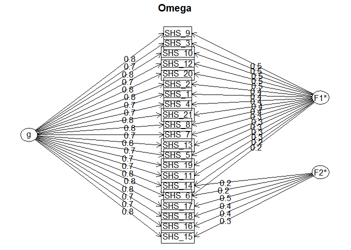

```
## Omega
## Call: omegah(m = m, nfactors = nfactors, fm = fm, key = key, flip = flip,
##     digits = digits, title = title, sl = sl, labels = labels,
##     plot = plot, n.obs = n.obs, rotate = rotate, Phi = Phi, option = option,
##     covar = covar)
## Alpha:                 0.98
## G.6:                   0.98
## Omega Hierarchical:    0.81
## Omega H asymptotic:    0.83
## Omega Total            0.98
##
## Schmid Leiman Factor loadings greater than  0.2
##           g   F1*   F2*   h2   u2   p2
## SHS_1  0.72  0.44       0.71 0.29 0.73
## SHS_2  0.75  0.45       0.77 0.23 0.74
## SHS_3  0.66  0.48       0.67 0.33 0.65
## SHS_4  0.75  0.43       0.74 0.26 0.75
## SHS_5  0.72  0.32       0.64 0.36 0.82
## SHS_6  0.80  0.24  0.23 0.75 0.25 0.85
## SHS_7  0.73  0.34       0.66 0.34 0.81
## SHS_8  0.78  0.35       0.75 0.25 0.82
## SHS_9  0.76  0.48       0.81 0.19 0.71
## SHS_10 0.76  0.47       0.80 0.20 0.73
## SHS_11 0.74  0.28       0.64 0.36 0.84
## SHS_12 0.75  0.46       0.77 0.23 0.72
## SHS_13 0.81  0.33       0.79 0.21 0.84
## SHS_14 0.75  0.24  0.20 0.67 0.33 0.85
## SHS_15 0.78        0.34 0.75 0.25 0.82
## SHS_16 0.70        0.36 0.62 0.38 0.79
## SHS_17 0.78        0.48 0.83 0.17 0.73
## SHS_18 0.74        0.42 0.73 0.27 0.76
## SHS_19 0.74  0.30       0.66 0.34 0.84
## SHS_20 0.76  0.46       0.79 0.21 0.73
## SHS_21 0.76  0.36       0.71 0.29 0.81
##
## With Sums of squares  of:
##     g   F1*   F2*
## 11.84  2.56  0.86
##
## general/max  4.62   max/min =   3
```

[output cut: 15 more lines]

```
##
## RMSEA index =  0.143  and the 10 % confidence intervals are  0.137 0.149
## BIC =  705.17
##
## Measures of factor score adequacy
##                                                  g   F1*   F2*
## Correlation of scores with factors            0.91  0.70  0.68
## Multiple R square of scores with factors      0.83  0.49  0.47
## Minimum correlation of factor score estimates 0.67 -0.02 -0.06
##
##  Total, General and Subset omega for each subset
##                                                  g  F1*  F2*
## Omega total for total scores and subscales    0.98 0.97 0.91
## Omega general for total scores and subscales  0.81 0.78 0.71
## Omega group for total scores and subscales    0.14 0.20 0.20
```

### PANAS

```r
# PANAS_pos
data %>%
  select(paste0("PANAS_", seq(1, 10, 2))) %>%
  omega(nfactors = 1)
```

```
## Omega_h for 1 factor is not meaningful, just omega_t
```

```
## Omega
## Call: omegah(m = m, nfactors = nfactors, fm = fm, key = key, flip = flip,
##     digits = digits, title = title, sl = sl, labels = labels,
##     plot = plot, n.obs = n.obs, rotate = rotate, Phi = Phi, option = option,
##     covar = covar)
## Alpha:                 0.82
## G.6:                   0.81
## Omega Hierarchical:    0.83
## Omega H asymptotic:    1
## Omega Total            0.83
##
## Schmid Leiman Factor loadings greater than  0.2
##            g  F1*   h2   u2 p2
## PANAS_1 0.76      0.57 0.43  1
## PANAS_3 0.74      0.55 0.45  1
## PANAS_5 0.90      0.81 0.19  1
## PANAS_7 0.45      0.21 0.79  1
## PANAS_9 0.61      0.37 0.63  1
##
## With Sums of squares  of:
##   g F1*
## 2.5 0.0
##
## general/max  Inf   max/min =   NaN
## mean percent general =  1    with sd =  0 and cv of  0
## Explained Common Variance of the general factor =  1
##
## The degrees of freedom are 5  and the fit is  0.1
## The number of observations was  432  with Chi Square =  43.35  with prob <  0.000000031
## The root mean square of the residuals is  0.06
## The df corrected root mean square of the residuals is  0.08
## RMSEA index =  0.133  and the 10 % confidence intervals are  0.099 0.171
## BIC =  13.01
##
## Compare this with the adequacy of just a general factor and no group factors
## The degrees of freedom for just the general factor are 5  and the fit is  0.1
## The number of observations was  432  with Chi Square =  43.35  with prob <  0.000000031
## The root mean square of the residuals is  0.06
## The df corrected root mean square of the residuals is  0.08
##
## RMSEA index =  0.133  and the 10 % confidence intervals are  0.099 0.171
## BIC =  13.01
##
## Measures of factor score adequacy
##                                                  g F1*
## Correlation of scores with factors            0.94   0
## Multiple R square of scores with factors      0.89   0
## Minimum correlation of factor score estimates 0.77  -1
##
##  Total, General and Subset omega for each subset
##                                                  g  F1*
## Omega total for total scores and subscales    0.83 0.83
## Omega general for total scores and subscales  0.83 0.83
## Omega group for total scores and subscales    0.00 0.00
```

```r
# PANAS_neg
data %>%
  select(paste0("PANAS_", seq(2, 10, 2))) %>%
  omega(nfactors = 1)
```

```
## Omega_h for 1 factor is not meaningful, just omega_t
```

```
## Omega
## Call: omegah(m = m, nfactors = nfactors, fm = fm, key = key, flip = flip,
##     digits = digits, title = title, sl = sl, labels = labels,
##     plot = plot, n.obs = n.obs, rotate = rotate, Phi = Phi, option = option,
##     covar = covar)
## Alpha:                 0.92
## G.6:                   0.92
## Omega Hierarchical:    0.92
## Omega H asymptotic:    1
## Omega Total            0.92
##
## Schmid Leiman Factor loadings greater than  0.2
##             g  F1*   h2   u2 p2
## PANAS_2  0.86      0.73 0.27  1
## PANAS_4  0.81      0.65 0.35  1
## PANAS_6  0.81      0.66 0.34  1
## PANAS_8  0.89      0.79 0.21  1
## PANAS_10 0.83      0.69 0.31  1
##
## With Sums of squares  of:
##   g F1*
## 3.5 0.0
##
## general/max  Inf   max/min =   NaN
## mean percent general =  1    with sd =  0 and cv of  0
## Explained Common Variance of the general factor =  1
##
## The degrees of freedom are 5  and the fit is  0.25
## The number of observations was  432  with Chi Square =  106.13  with prob <  0.0000000000000000000027
## The root mean square of the residuals is  0.05
## The df corrected root mean square of the residuals is  0.07
## RMSEA index =  0.216  and the 10 % confidence intervals are  0.182 0.253
## BIC =  75.78
##
## Compare this with the adequacy of just a general factor and no group factors
## The degrees of freedom for just the general factor are 5  and the fit is  0.25
## The number of observations was  432  with Chi Square =  106.13  with prob <  0.0000000000000000000027
## The root mean square of the residuals is  0.05
## The df corrected root mean square of the residuals is  0.07
##
## RMSEA index =  0.216  and the 10 % confidence intervals are  0.182 0.253
## BIC =  75.78
##
## Measures of factor score adequacy
##                                                  g F1*
## Correlation of scores with factors            0.96   0
## Multiple R square of scores with factors      0.93   0
## Minimum correlation of factor score estimates 0.85  -1
##
##  Total, General and Subset omega for each subset
##                                                  g  F1*
## Omega total for total scores and subscales    0.92 0.92
## Omega general for total scores and subscales  0.92 0.92
## Omega group for total scores and subscales    0.00 0.00
```

# t-tests

In this section, we will: (a) test assumptions of normality, (b) transform variables violating assumptions, (c) test assumptions of homoscedasticity, (d) identify and winsorize outliers, and (e) conduct the t-tests.

## Normality

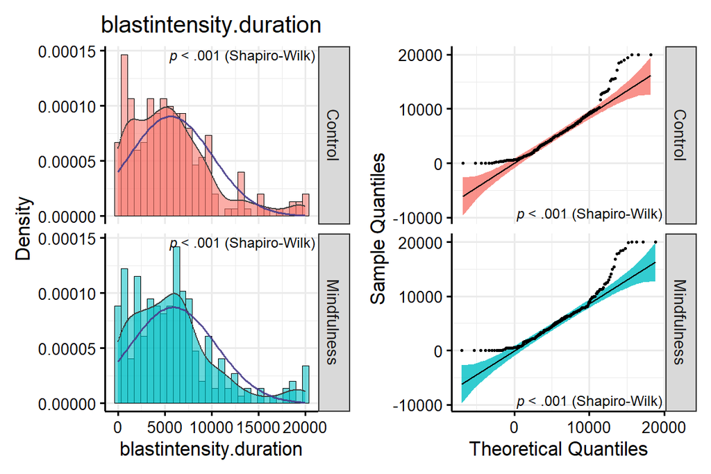

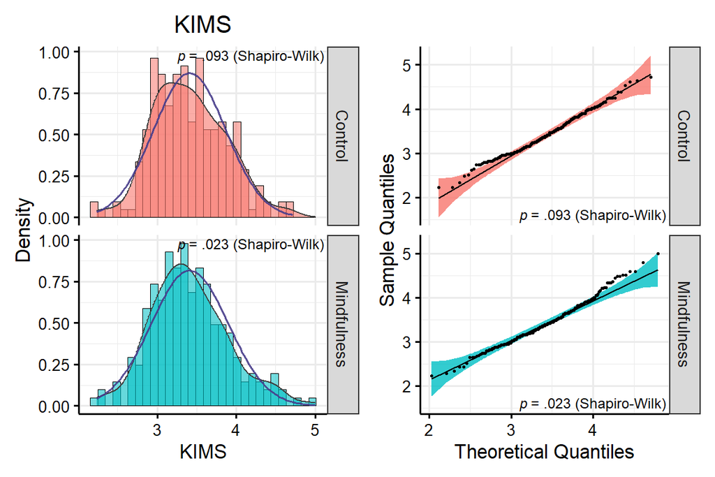

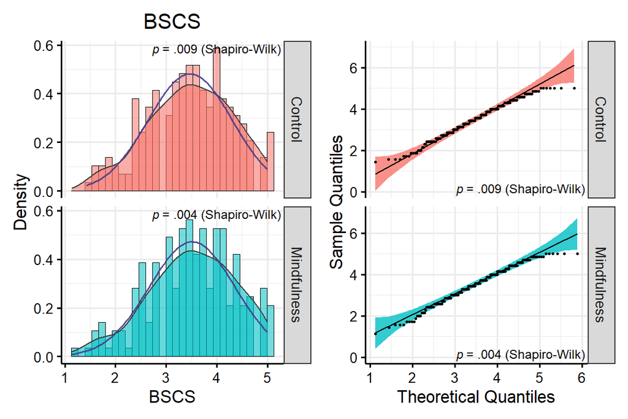

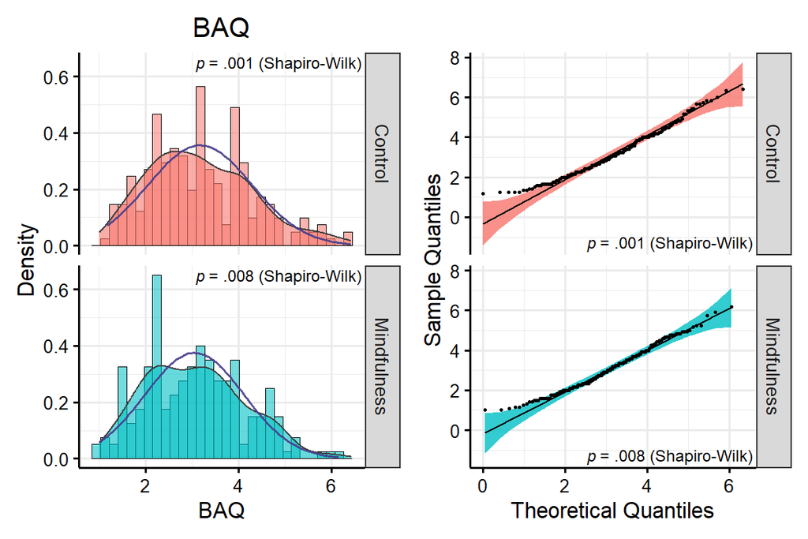

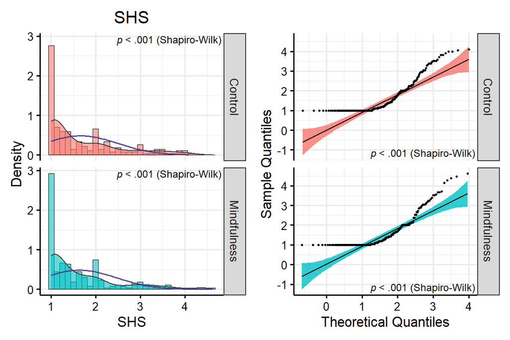

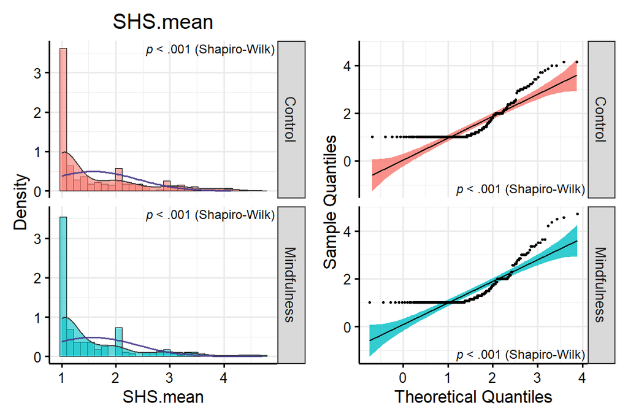

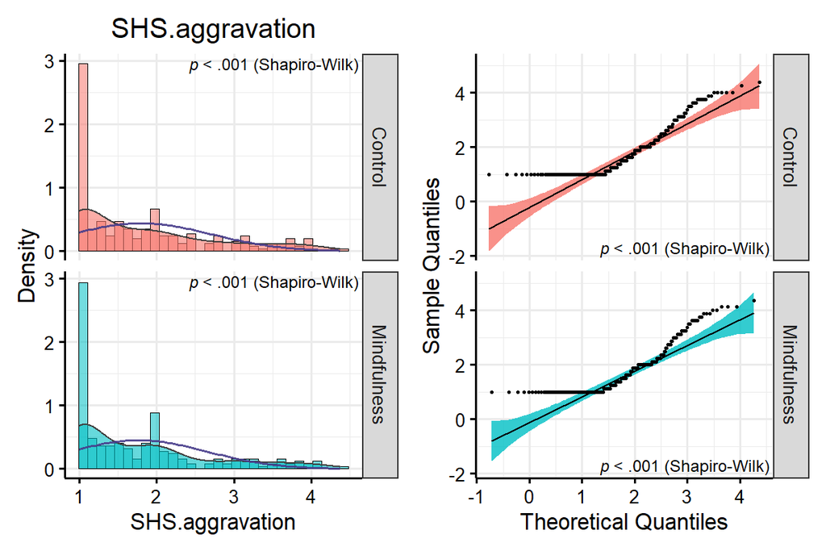

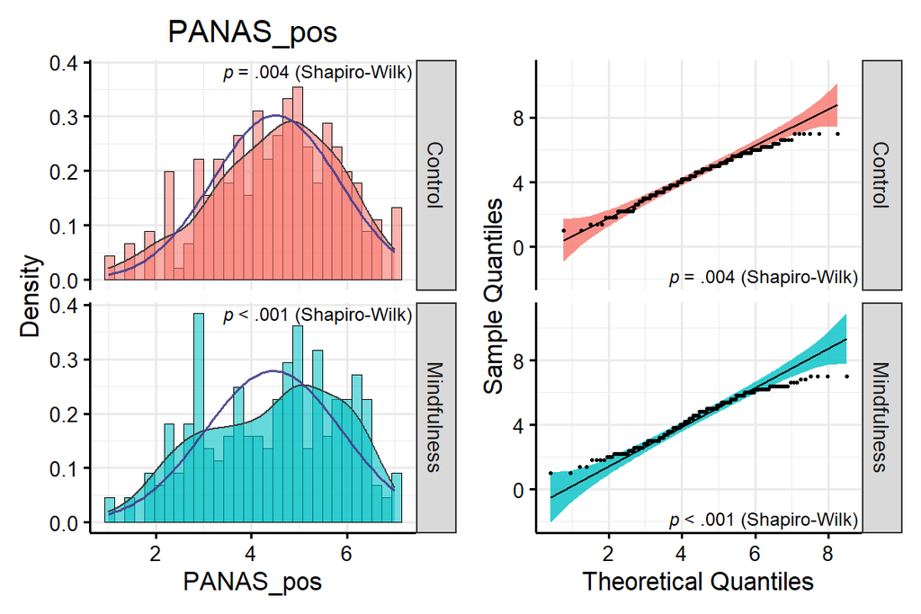

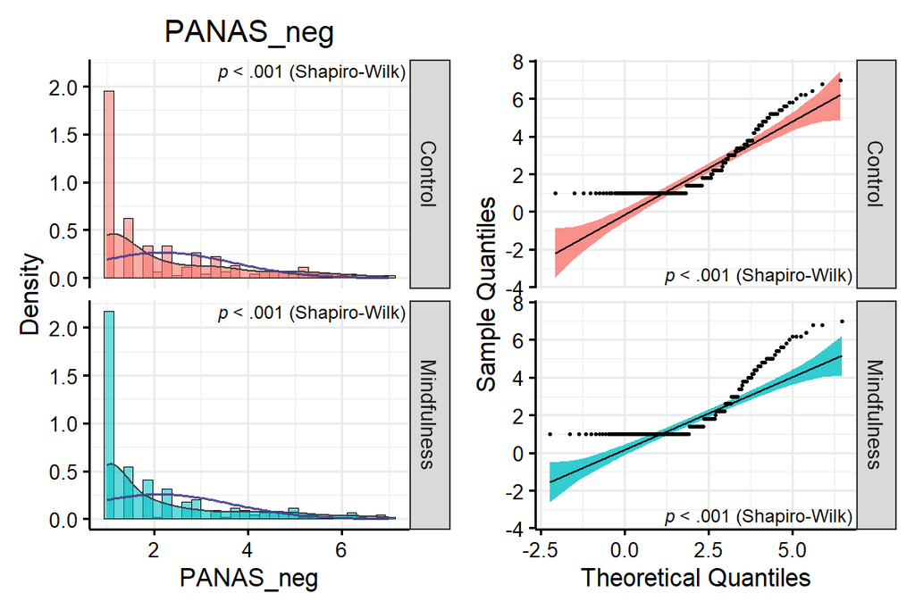

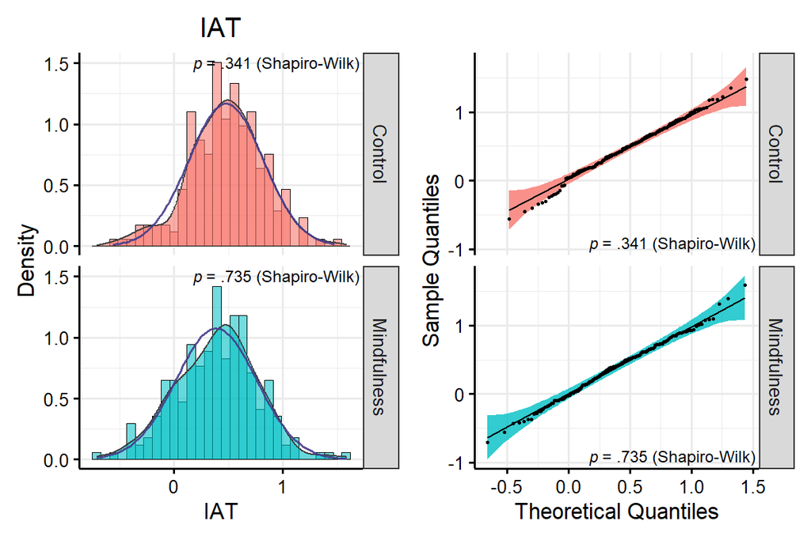

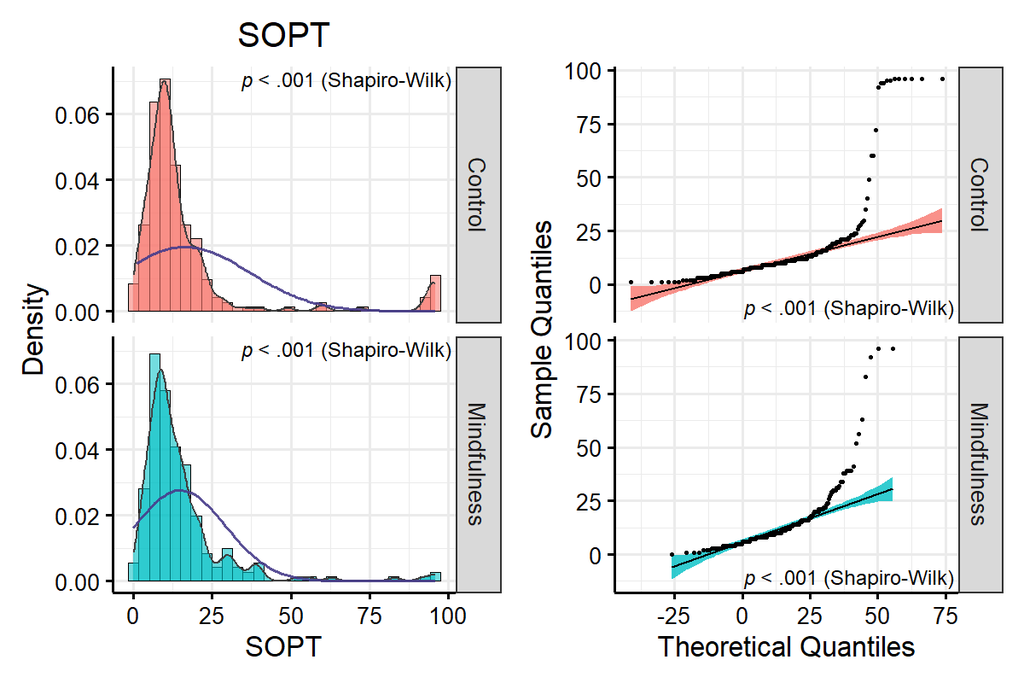

```r
lapply(col.list, function(x)
  nice_normality(data,
                 variable = x,
                 title = x,
                 group = "condition",
                 shapiro = TRUE,
                 histogram = TRUE))
```

## Transformation

```r
predict_bestNormalize <- function(var) {
  x <- bestNormalize(var, standardize = FALSE, allow_orderNorm = FALSE)
  print(cur_column())
  print(x$chosen_transform)
  cat("\n")
  predict(x)
}

set.seed(100)
data <- data %>%
  mutate(across(all_of(col.list),
                predict_bestNormalize,
                .names = "{.col}.t"))
```

```
## [1] "blastintensity.duration"
## Non-Standardized sqrt(x + a) Transformation with 432 nonmissing obs.:
##  Relevant statistics:
##  - a = 0
##  - mean (before standardization) = 69.18617
##  - sd (before standardization) = 31.38282
##
## [1] "KIMS"
## Non-Standardized Yeo-Johnson Transformation with 432 nonmissing obs.:
##  Estimated statistics:
##  - lambda = -0.117135
##  - mean (before standardization) = 1.356875
##  - sd (before standardization) = 0.08979645
##
## [1] "BSCS"
## I(x) Transformation with 432 nonmissing obs.
##
## [1] "BAQ"
## Non-Standardized sqrt(x + a) Transformation with 432 nonmissing obs.:
##  Relevant statistics:
##  - a = 0
##  - mean (before standardization) = 1.736399
##  - sd (before standardization) = 0.3118
##
## [1] "SHS"
## Non-Standardized Box Cox Transformation with 432 nonmissing obs.:
##  Estimated statistics:
##  - lambda = -0.9999576
##  - mean (before standardization) = 0.2749845
##  - sd (before standardization) = 0.2587866
##
## [1] "SHS.mean"
## Non-Standardized Yeo-Johnson Transformation with 432 nonmissing obs.:
##  Estimated statistics:
##  - lambda = -2.955872
##  - mean (before standardization) = 0.3091423
##  - sd (before standardization) = 0.01506188
##
## [1] "SHS.aggravation"
## Non-Standardized Box Cox Transformation with 432 nonmissing obs.:
```

[output cut: 17 more lines]

```
##  - sd (before standardization) = 0.4655236
##
## [1] "IAT"
## Non-Standardized Yeo-Johnson Transformation with 432 nonmissing obs.:
##  Estimated statistics:
##  - lambda = 1.209594
##  - mean (before standardization) = 0.4626512
##  - sd (before standardization) = 0.3841587
##
## [1] "SOPT"
## Non-Standardized Yeo-Johnson Transformation with 432 nonmissing obs.:
##  Estimated statistics:
##  - lambda = -0.1080218
##  - mean (before standardization) = 2.170808
##  - sd (before standardization) = 0.5596047
```

```r
col.list <- paste0(col.list, ".t")
```

> *Note.* The I(x) transformations above are actually not transformations, but a shorthand function for passing the data “as is”. Suggesting the package estimated the various attempted transformations did not improve normality in those cases, so no transformation is used. This only appears when standardize is set to FALSE. When set to TRUE, for those variables, it is actually center_scale(x), suggesting that the data are only CENTERED because they need no transformation (no need to be scaled), only to be centered.

Let’s check if normality was corrected.

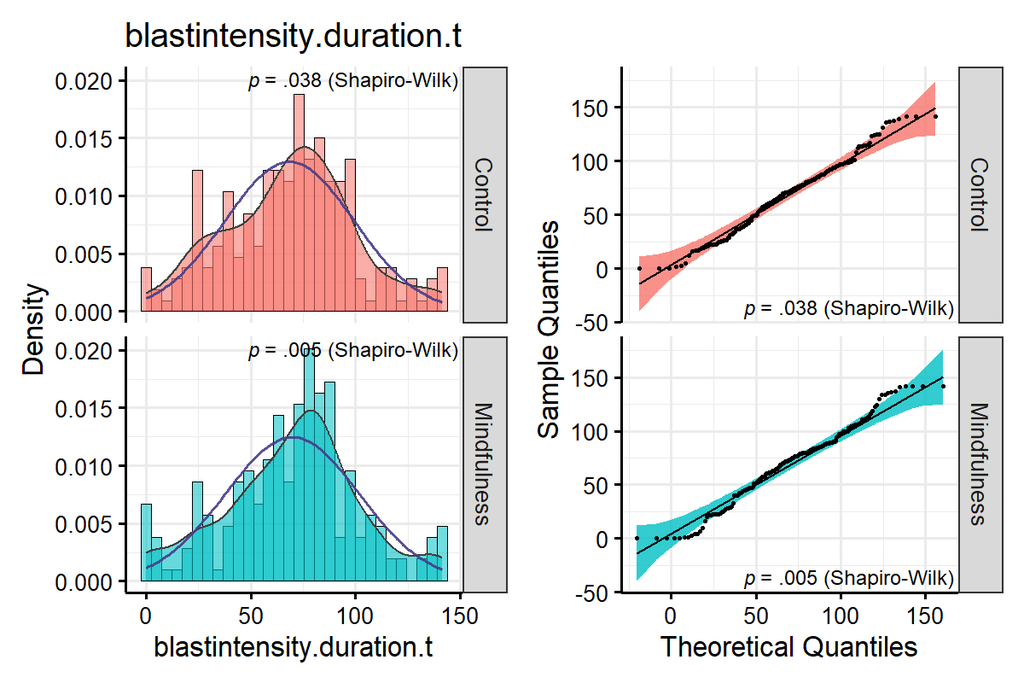

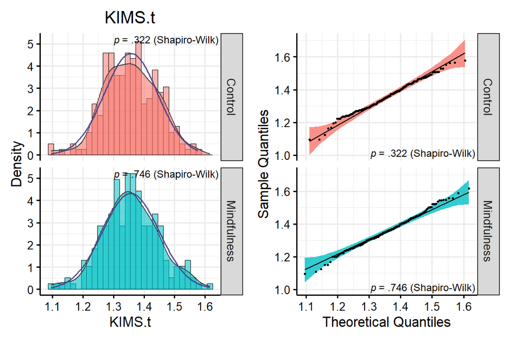

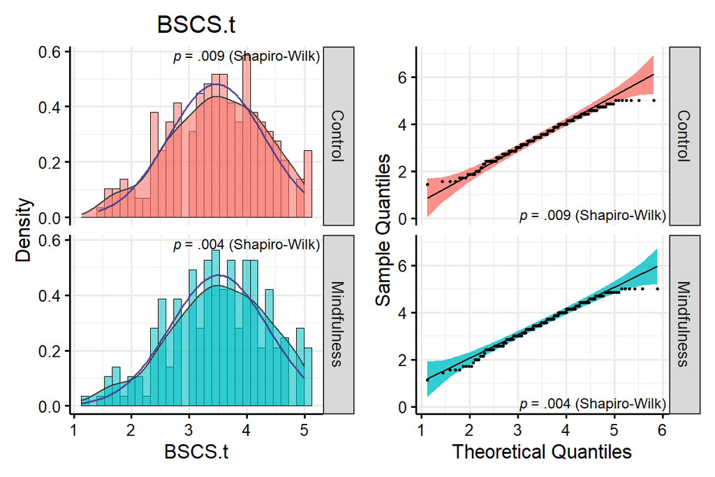

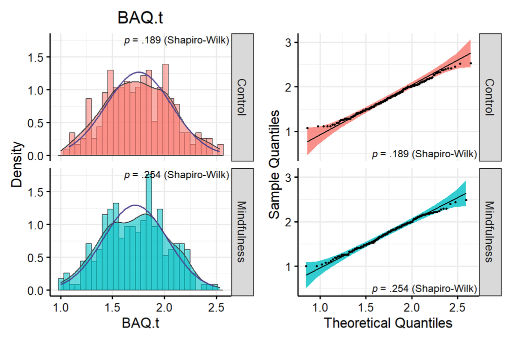

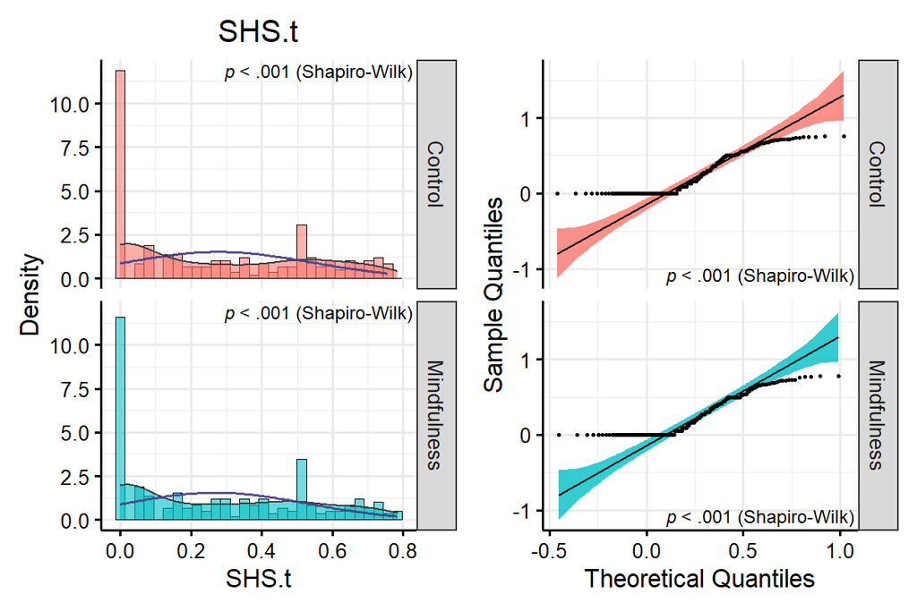

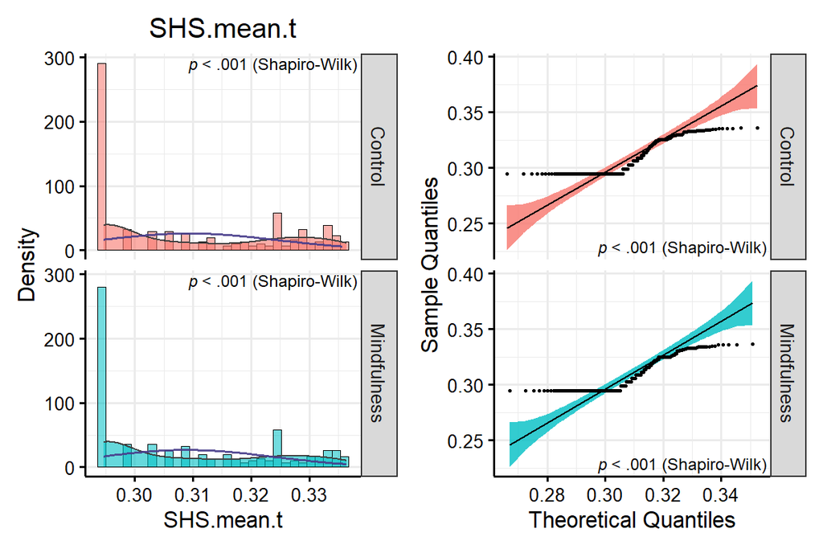

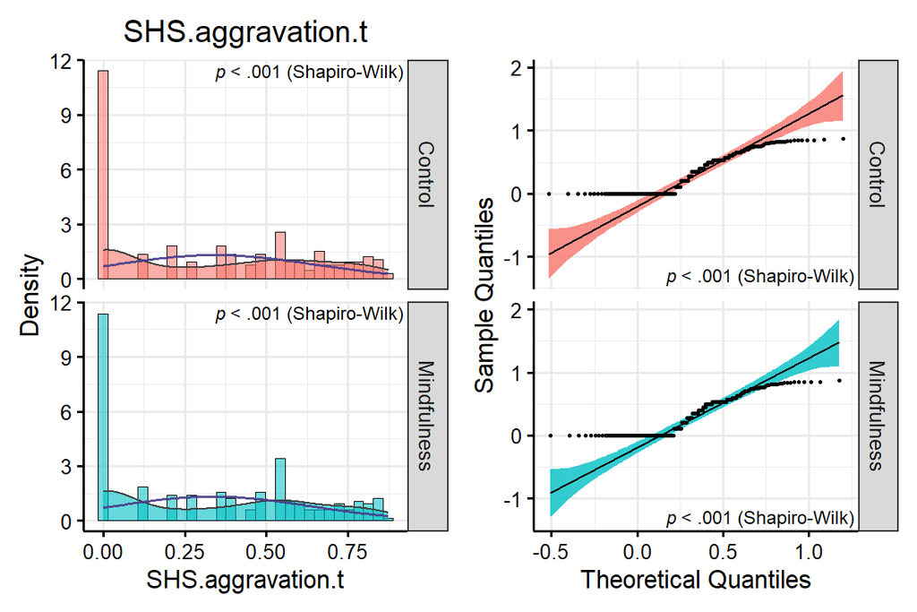

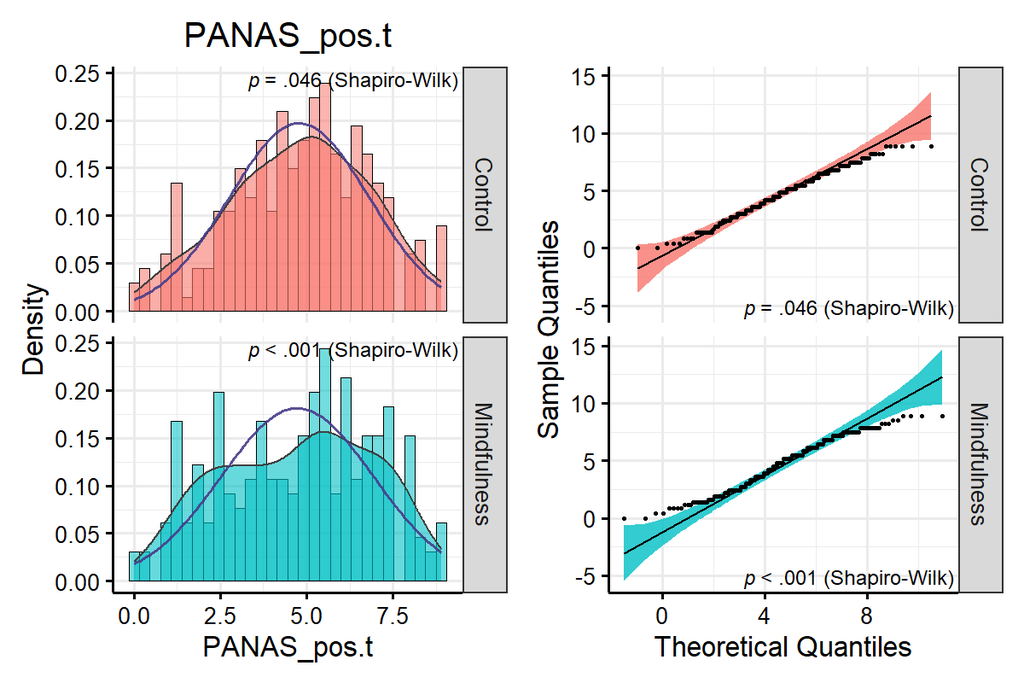

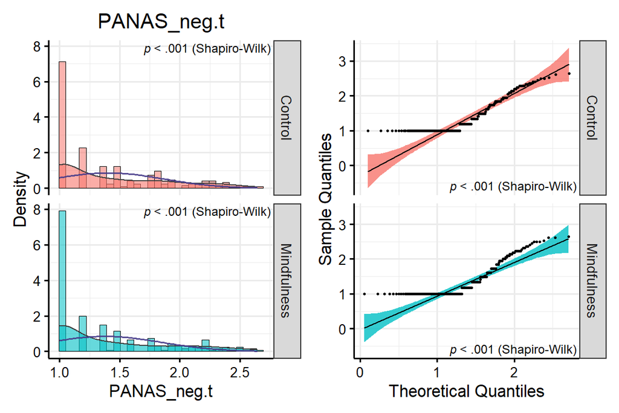

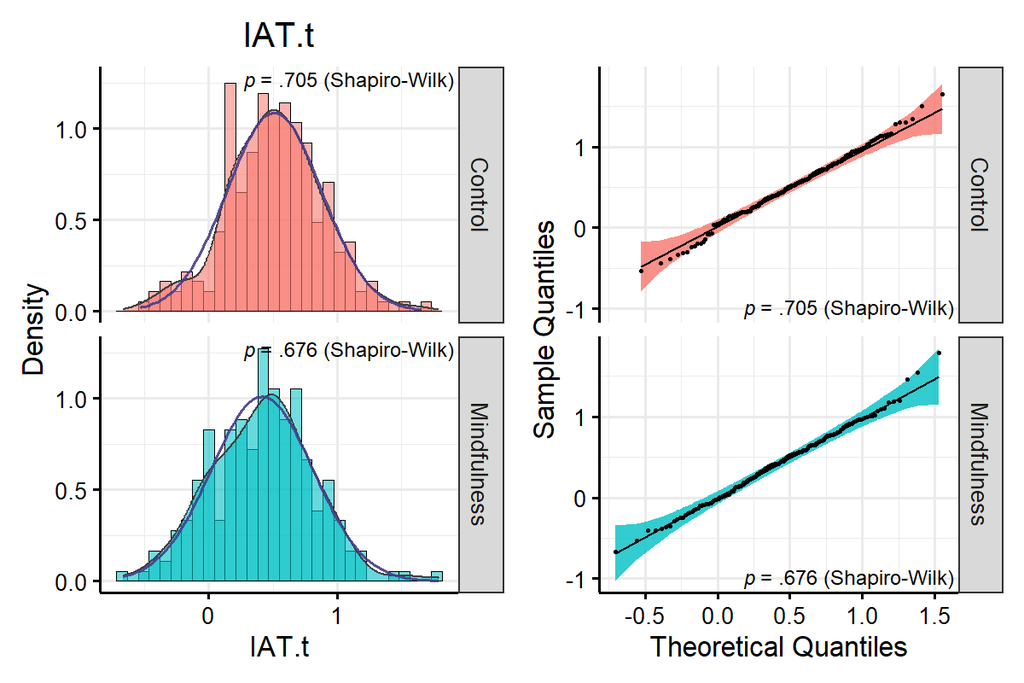

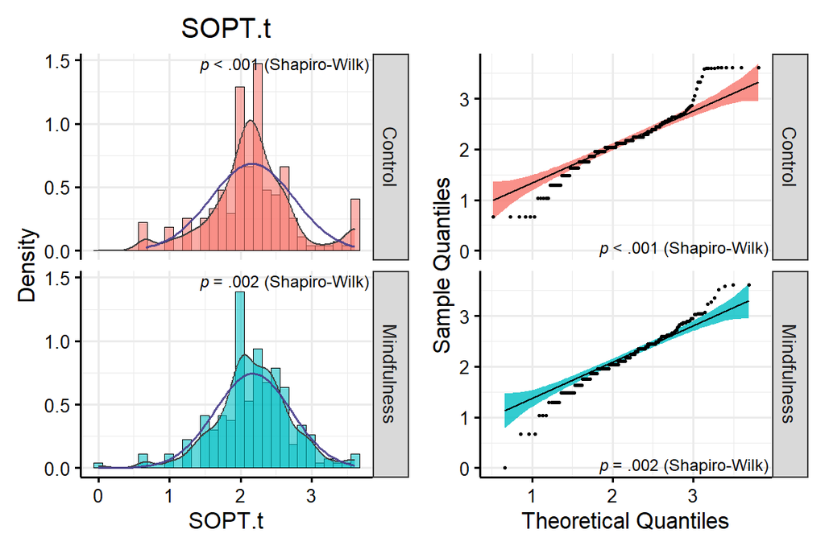

```r
# Group normality
lapply(col.list, function(x)
  nice_normality(data,
                 x,
                 "condition",
                 shapiro = TRUE,
                 title = x,
                 histogram = TRUE))
```

Looks rather reasonable now, though not perfect (fortunately t-tests are quite robust against violations of normality).

We can now resume with the next step: checking variance.

## Homoscedasticity

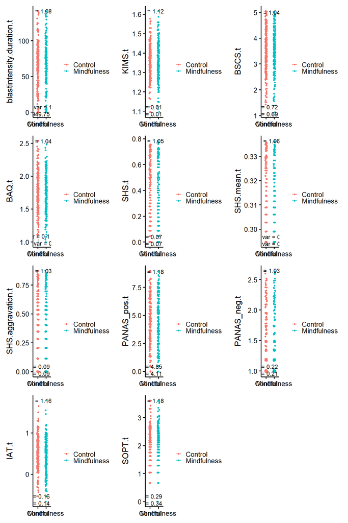

```r
# Plotting variance
plots(lapply(col.list, function(x) {
  nice_varplot(data, x, group = "condition")
  }),
  n_columns = 3)
```

Variance looks good. No group has four times the variance of any other group. We can now resume with checking outliers.

## Outliers

We check outliers visually with the `plot_outliers` function, which draws red lines at +/- 3 median absolute deviations.

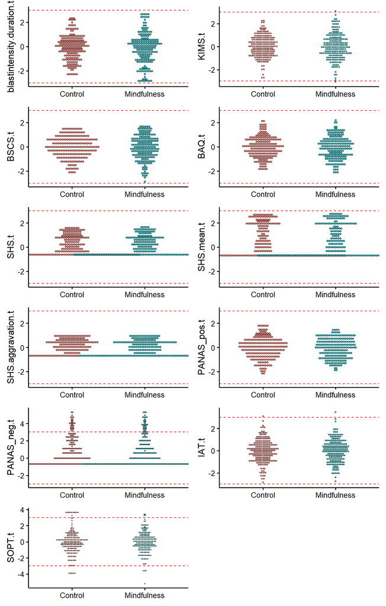

```r
plots(lapply(col.list, function(x) {
  plot_outliers(data, x, group = "condition", ytitle = x, binwidth = 0.15)
  }),
  n_columns = 2)
```

There are some outliers, but nothing unreasonable. Let’s still check with the 3 median absolute deviations (MAD) method.

```r
data %>%
  filter(condition == "Control") %>%
  find_mad(col.list, criteria = 3)
```

```
## 45 outlier(s) based on 3 median absolute deviations for variable(s):
##  blastintensity.duration.t, KIMS.t, BSCS.t, BAQ.t, SHS.t, SHS.mean.t, SHS.aggravation.t, PANAS_pos.t, PANAS_neg.t, IAT.t, SOPT.t
##
## The following participants were considered outliers for more than one variable:
##
##   Row n
## 1   4 2
## 2  21 2
## 3  45 2
## 4 189 2
##
## Outliers per variable:
##
## $PANAS_neg.t
##    Row PANAS_neg.t_mad
```

[output cut: 55 more lines]

```r
data %>%
  filter(condition == "Mindfulness") %>%
  find_mad(col.list, criteria = 3)
```

```
## 41 outlier(s) based on 3 median absolute deviations for variable(s):
##  blastintensity.duration.t, KIMS.t, BSCS.t, BAQ.t, SHS.t, SHS.mean.t, SHS.aggravation.t, PANAS_pos.t, PANAS_neg.t, IAT.t, SOPT.t
##
## The following participants were considered outliers for more than one variable:
##
##   Row n
## 1  82 2
## 2  97 2
## 3 104 2
## 4 160 2
##
## Outliers per variable:
##
## $KIMS.t
##   Row KIMS.t_mad
```

[output cut: 54 more lines]

### Multivariate outliers

For multivariate outliers, it is recommended to use the Minimum Covariance Determinant, a robust version of the Mahalanobis distance (MCD, Leys et al., 2019).

Leys, C., Delacre, M., Mora, Y. L., Lakens, D., & Ley, C. (2019). How to classify, detect, and manage univariate and multivariate outliers, with emphasis on pre-registration. *International Review of Social Psychology*, *32*(1).

```r
data.na <- na.omit(data[col.list])
x <- check_outliers(data.na, method = "mcd",
                    threshold = 200)
x
```

```
## 2 outliers detected: cases 94, 242.
## - Based on the following method and threshold: mcd (200).
## - For variables: blastintensity.duration.t, KIMS.t, BSCS.t, BAQ.t,
##   SHS.t, SHS.mean.t, SHS.aggravation.t, PANAS_pos.t, PANAS_neg.t, IAT.t,
##   SOPT.t.
```

[figure not shown]

```r
plot(x)
```

There are 2 multivariate outliers according to the MCD method using an artificially high threshold. However, we did not mention in the preregistration that we would exclude multivariate outliers, so we will not at this time.

## Winsorization

Visual assessment and the MAD method confirm we have some outlier values. We could ignore them but because they could have disproportionate influence on the models, one recommendation is to winsorize them by bringing the values at 3 SD. Instead of using the standard deviation around the mean, however, we use the absolute deviation around the median, as it is more robust to extreme observations. For a discussion, see:

Leys, C., Klein, O., Bernard, P., & Licata, L. (2013). Detecting outliers: Do not use standard deviation around the mean, use absolute deviation around the median. *Journal of Experimental Social Psychology, 49*(4), 764–766. https://doi.org/10.1016/j.jesp.2013.03.013

```r
# Winsorize variables of interest with MAD
data <- data %>%
  group_by(condition) %>%
  mutate(across(all_of(col.list),
                winsorize_mad,
                .names = "{.col}.w")) %>%
  ungroup()

col.list <- paste0(col.list, ".w")
```

## Standardization

We can now standardize our variables.

```r
data <- data %>%
  mutate(across(all_of(col.list), standardize, .names = "{col}.s"))

# Update col.list
col.list <- paste0(col.list, ".s")
```

We are now ready to compare the group condition (Control vs. Mindfulness Priming) across our different variables with the t-tests.

## t-tests

```r
nice_t_test(data,
            response = col.list,
            group = "condition") %>%
  nice_table(highlight = 0.10, width = .80)
```

```
## Using Welch t-test (base R's default; cf. https://doi.org/10.5334/irsp.82).
## For the Student t-test, use `var.equal = TRUE`.
##
```

| Dependent Variable | t | df | p | d | 95% CI |
| --- | --- | --- | --- | --- | --- |
| blastintensity.duration.t.w.s | -0.46 | 428.64 | .647 | -0.04 | [-0.23, 0.14] |
| KIMS.t.w.s | 0.05 | 427.80 | .956 | 0.01 | [-0.18, 0.19] |
| BSCS.t.w.s | -0.48 | 429.37 | .630 | -0.05 | [-0.24, 0.14] |
| BAQ.t.w.s | 1.12 | 430.00 | .262 | 0.11 | [-0.08, 0.30] |
| SHS.t.w.s | 0.30 | 429.99 | .762 | 0.03 | [-0.16, 0.22] |
| SHS.mean.t.w.s | 0.24 | 429.95 | .812 | 0.02 | [-0.17, 0.21] |
| SHS.aggravation.t.w.s | 0.25 | 430.00 | .799 | 0.02 | [-0.16, 0.21] |
| PANAS_pos.t.w.s | 0.25 | 425.68 | .801 | 0.02 | [-0.16, 0.21] |
| PANAS_neg.t.w.s | 0.72 | 429.81 | .475 | 0.07 | [-0.12, 0.26] |
| IAT.t.w.s | 2.63 | 426.88 | .009** | 0.25 | [0.06, 0.44] |
| SOPT.t.w.s | -0.39 | 429.75 | .696 | -0.04 | [-0.23, 0.15] |

Let’s also compute non-parametric Mann-Whitney-Wilcoxon tests for skewed variables negative affect and hostility.

```r
skewed <- c("SHS", "SHS.mean", "SHS.aggravation", "PANAS_neg")

lapply(skewed, \(x) {
  forms <- as.formula(paste(x, "~", "condition"))
  y <- wilcox.test(forms, data = data) %>%
    report(data = data)
  print(y)
  as.data.frame(y)
}) %>%
  bind_rows() %>%
  nice_table(highlight = TRUE)
```

```
## Effect sizes were labelled following Funder's (2019) recommendations.
##
## The Wilcoxon rank sum test with continuity correction testing the difference in
## ranks between SHS and condition suggests that the effect is positive,
## statistically not significant, and tiny (W = 23657.00, p = 0.796; r (rank
## biserial) = 0.01, 95% CI [-0.09, 0.12])
## Effect sizes were labelled following Funder's (2019) recommendations.
##
## The Wilcoxon rank sum test with continuity correction testing the difference in
## ranks between SHS.mean and condition suggests that the effect is positive,
## statistically not significant, and tiny (W = 23457.00, p = 0.917; r (rank
## biserial) = 5.62e-03, 95% CI [-0.10, 0.11])
## Effect sizes were labelled following Funder's (2019) recommendations.
##
## The Wilcoxon rank sum test with continuity correction testing the difference in
## ranks between SHS.aggravation and condition suggests that the effect is
## positive, statistically not significant, and tiny (W = 23618.50, p = 0.818; r
## (rank biserial) = 0.01, 95% CI [-0.10, 0.12])
## Effect sizes were labelled following Funder's (2019) recommendations.
##
## The Wilcoxon rank sum test with continuity correction testing the difference in
## ranks between PANAS_neg and condition suggests that the effect is positive,
## statistically not significant, and tiny (W = 24312.00, p = 0.428; r (rank
## biserial) = 0.04, 95% CI [-0.07, 0.15])
```

| Parameter1 | Parameter2 | W | p | Method | Alternative | rrb | 95% CI (rrb) |
| --- | --- | --- | --- | --- | --- | --- | --- |
| SHS | condition | 23,657.00 | .796 | Wilcoxon rank sum test | two.sided | 0.01 | [-0.09, 0.12] |
| SHS.mean | condition | 23,457.00 | .917 | Wilcoxon rank sum test | two.sided | 0.01 | [-0.10, 0.11] |
| SHS.aggravation | condition | 23,618.50 | .818 | Wilcoxon rank sum test | two.sided | 0.01 | [-0.10, 0.12] |
| PANAS_neg | condition | 24,312.00 | .428 | Wilcoxon rank sum test | two.sided | 0.04 | [-0.07, 0.15] |

## Violin plots

### Intensity * Duration

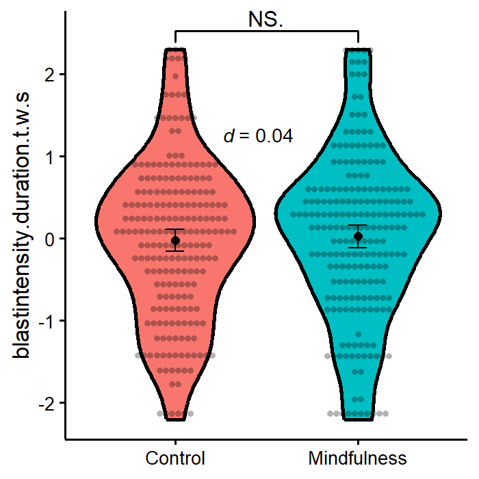

```r
nice_violin(data,
            group = "condition",
            response = "blastintensity.duration.t.w.s",
            comp1 = 1,
            comp2 = 2,
            obs = TRUE,
            has.d = TRUE,
            d.y = 1)
```

## Means, SD

Let’s extract the means and standard deviations for journal reporting.

### Intensity * Duration

```r
data %>%
    group_by(condition) %>%
    summarize(M = mean(blastintensity.duration),
              SD = sd(blastintensity.duration),
              N = n()) %>%
  nice_table(width = 0.40)
```

| condition | M | SD | N |
| --- | --- | --- | --- |
| Control | 5,637.74 | 4,417.87 | 218 |
| Mindfulness | 5,903.38 | 4,578.75 | 214 |

# Moderations (confirmatory)

Let’s see if our variables don’t interact together with our experimental condition. But first, let’s test the models assumptions.

## Assumptions

### Intensity * Duration

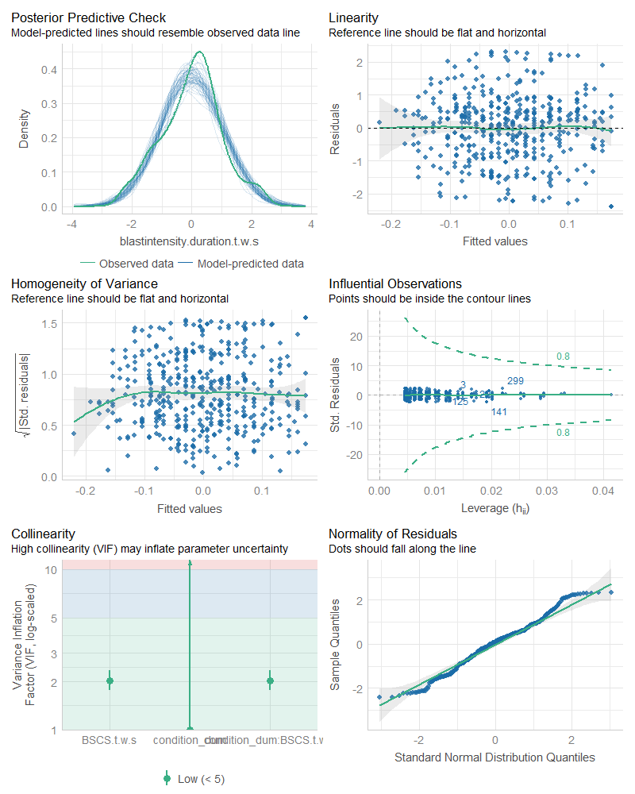

```r
mod1 <- lm(blastintensity.duration.t.w.s ~ condition_dum*BSCS.t.w.s,
           data = data, na.action="na.exclude")
check_model(mod1)
```

### Affect

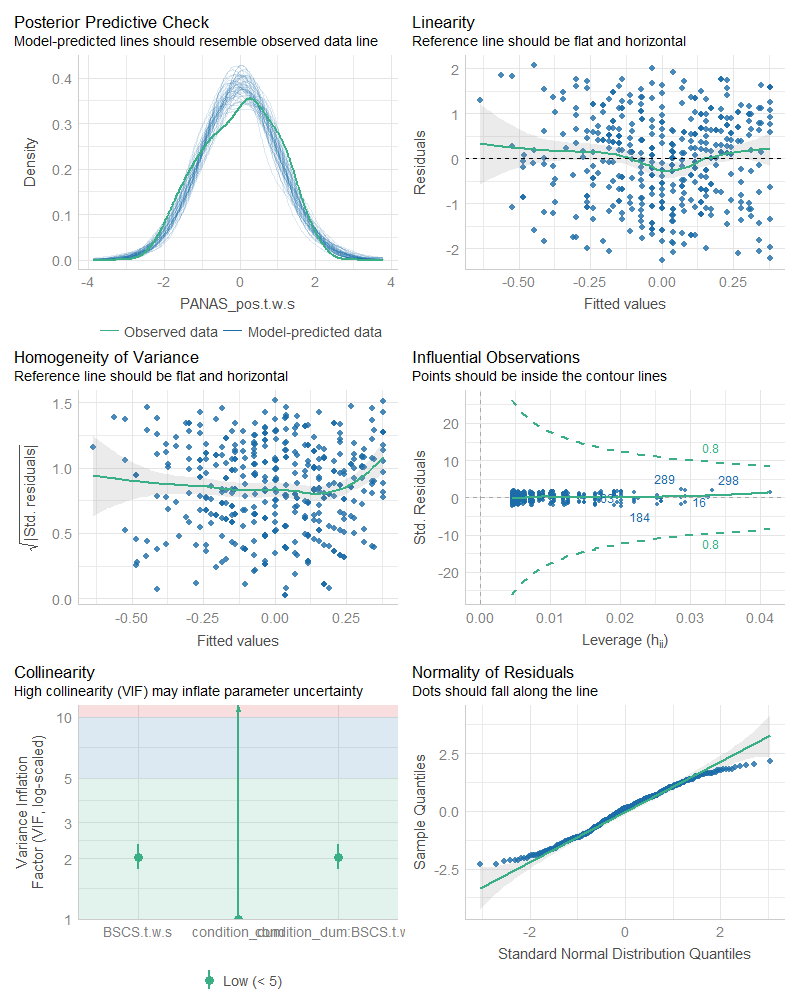

```r
mod2 <- lm(PANAS_pos.t.w.s ~ condition_dum*BSCS.t.w.s,
           data = data, na.action="na.exclude")
check_model(mod2)
```

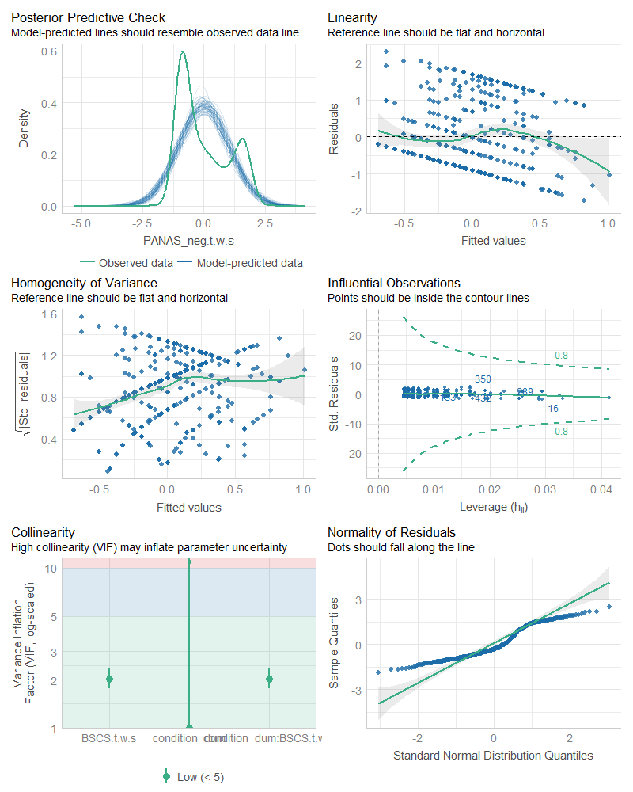

```r
mod3 <- lm(PANAS_neg.t.w.s ~ condition_dum*BSCS.t.w.s,
           data = data, na.action="na.exclude")
check_model(mod3)
```